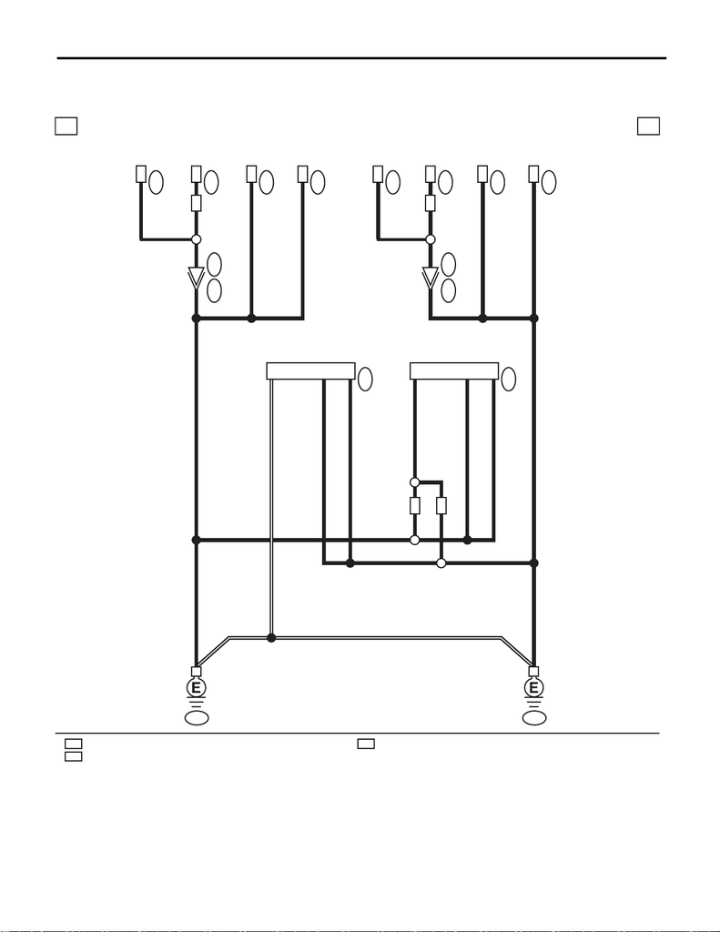

WI-60

Ground Circuit

WIRING SYSTEM

5. Ground Circuit

A: WIRING DIAGRAM

WI-44270

a a

EL

HL FF

F14

F27

F125

B

B

F17

B

B1

F15

B1

B13

B2

2

F13

B1

B5

B/WB/W 7

F47

F5

B1

B1

F10

B1

GB-2GB-1

F126

EL

B2

B5

BB

B

7

HL

B/W B/W

3

F6 F1

BB

3

F21 F4

BB

FF

FF

MAIN FAN RELAY 2

FRONT FOG LIGHT LH

HORN

FRONT TURN

SIGNAL LIGHT RH

HORN

FRONT FOG LIGHT RH

FRONT COMBINATION LIGHT LH

FRONT COMBINATION LIGHT RH

MAIN FAN MOTOR

FRONT TURN

SIGNAL LIGHT LH

: HALOGEN MODEL : WITH FRONT FOG LIGHT

: EXCEPT FOR HALOGEN MODEL

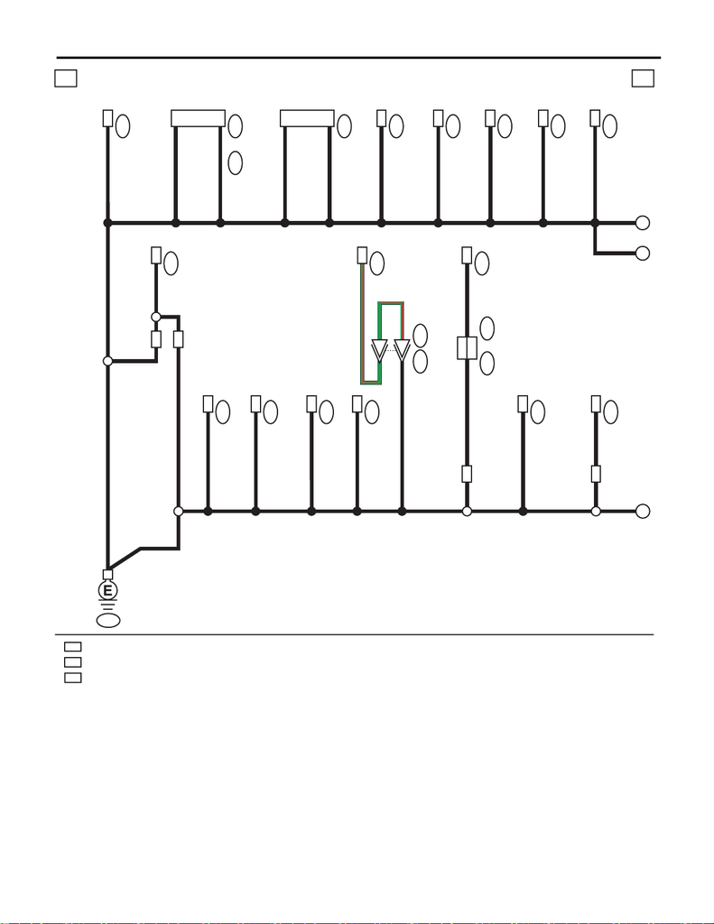

WI-61

Ground Circuit

WIRING SYSTEM

WI-44271

b b

B396

B32

B475

B152

D:

FA

B2

B

BB

B

D8

B7

B3

OP

B

1

B180

EJ

GB-3

C

FA

OP

B57

B1

B558

B:

B70

A:

B A10

BB2

B3

B12

B8

B16

B4

B2

B10

B3

B68

B2

B164

2B

B426

B2

B225

G/R 9

F134

B2

G/R

G/R

G/R

F37

A:

B143

B:

B14 A16

M/B

B

1B

B

B

B

1

: WITHOUT PUSH BUTTON START : 3

WITH PUSH BUTTON START : 4

: ENGINE TYPE FA

WIPER RELAY

TURN SIGNAL &

HAZARD MODULE

WASHER FLUID LEVEL SENSOR

REMOTE ENGINE

START CM

F/B

: WITHOUT PUSH BUTTON START

: ENGINE TYPE EJ

POWER TRANSISTOR

B71

COMBINATION SWITCH

(LIGHTING)

COMBINATION SWITCH

(WIPER)

FRONT WIPER MOTOR

PRESSURE SWITCH

ROLL CONNECTOR

EJ

FA

ACCESSORY RELAY

(PUSH BUTTON START)

VACUUM PUMP

B124

KEY LOCK

1

2

B181 B182

POWER WINDOW RELAY

KEYLESS BUZZER

A

B

B

B

BRAKE FLUID LEVEL SWITCH

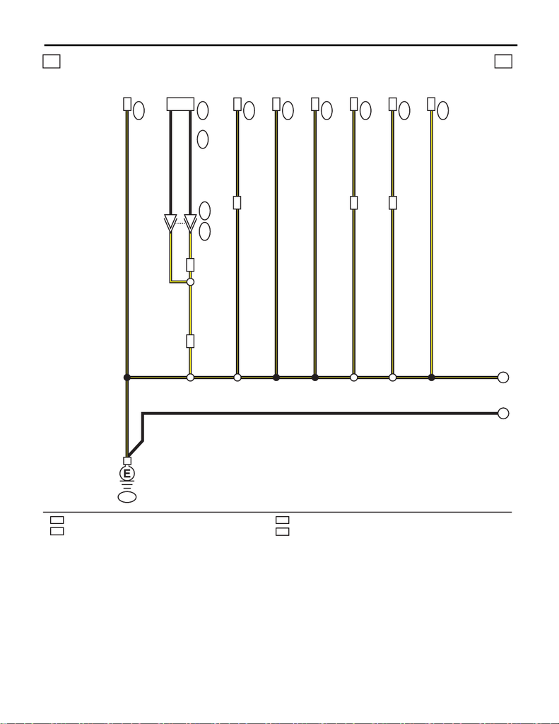

WI-62

Ground Circuit

WIRING SYSTEM

WI-44272

WP

SC

AH

ID

c c

B/Y

B

B559

B367

B150

B422

B231

E

D

SC

ID

AH

5

5

1

7

2

B/Y

B40

4B/Y

B/Y

B/Y

B/Y

B

B/Y

B/Y

GB-4

B280

A:

B/Y A1

B575 B576

BB/Y A11

BB/YB/Y B15

20

12

B573B572

WP

B:A:

ID

IMPACT SENSOR

AUTO HEADLIGHT BEAM LEVELER CM

STEERING ANGLE SENSOR

ID CODE BOX

SECURITY CM

DATA LINK CONNECTOR

BODY INTEGRATED UNIT

KEYLESS ACCESS CM

: WITH SECURITY CM

: WITH PUSH BUTTON START : WITH ID CODE BOX

: WITH AUTO HEADLIGHT BEAM LEVELER

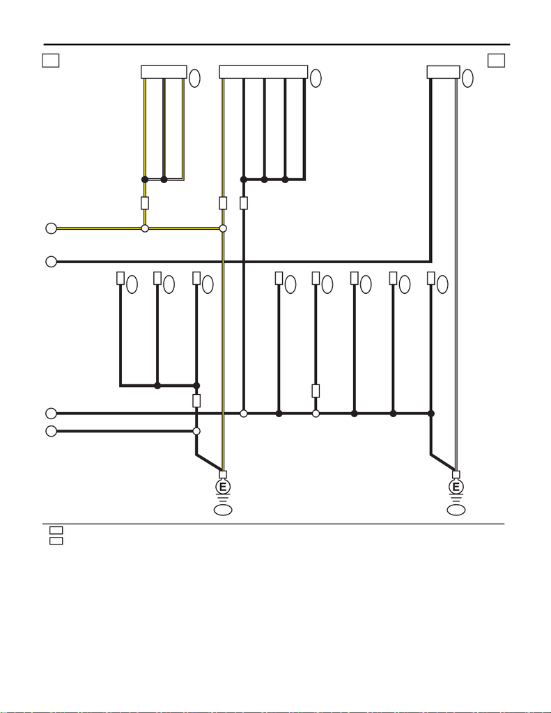

WI-63

Ground Circuit

WIRING SYSTEM

WI-44273

d d

E

D

C

B225

B225

B225

AB6

B/W

B

B/Y

B

B/Y

B

31B

35B

39B

A26

A25

B/W

B

GB-5 GB-6

WP

B

B/Y

B/Y

B/Y

B

B

B/Y

B

B

CVT

EJ

EJ

B116

B380

4

2

8

30

17

29

28

31

B321

B220

B177

B220

B424

2B

1

B

39B

1B

5B

A

B

WP

WP

EJ

A:

AIRBAG CM

IG RELAY 1 (PUSH BUTTON START)

IG RELAY 2 (PUSH BUTTON START)

STARTER RELAY (PUSH BUTTON START)

: WITH PUSH BUTTON START

SELECT LEVER

DCCD CM

FUEL PUMP RELAY

WIPER DEICER

SEAT HEATER RELAY

HOOD SWITCH

STEERING LOCK CM

: ENGINE TYPE EJ

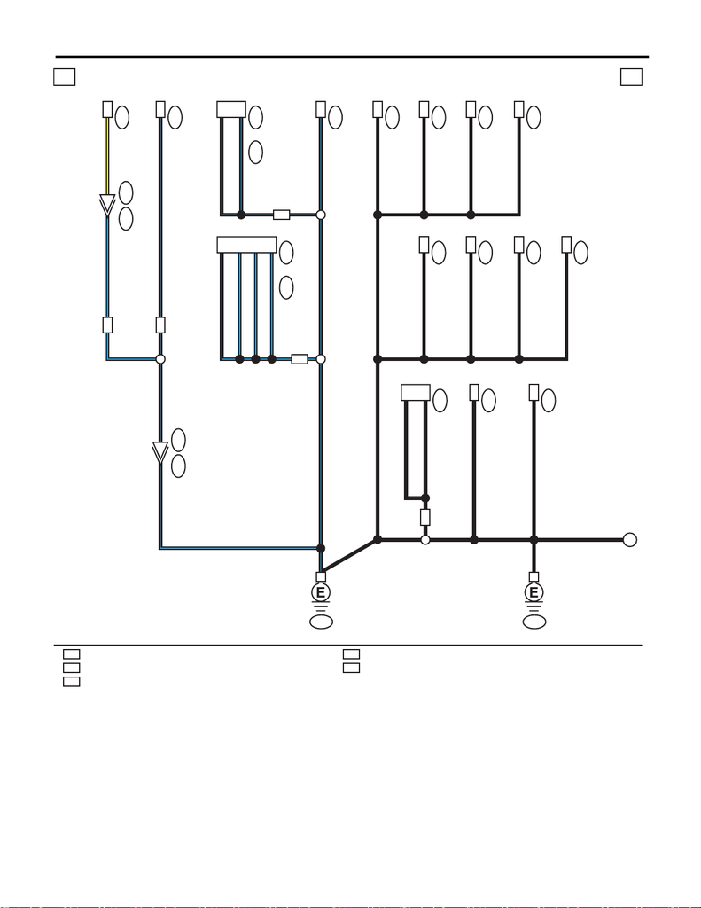

WI-64

Ground Circuit

WIRING SYSTEM

WI-46868

e e

B/L

B/L

BB

i29

R284

AD7

ON

i87

C:

i50

A:

i86

B:

i85

A:

i195 R382

R34 AD6

WN

B/L 1

B/L B10

B/L B7

B/L A12

B/L A10

B/L 5

B/L B/Y 5

A7

C6

B/L

B/L

GB-8GB-7

FA

EJ

WP

5

B

B

B

B

B

1

1

5

4

B34

BA2

B3

B6

B38

B3

B3

C1B

i10

i28

i84

C:

i13

i88

i22

i234

i122

A:

i24

i150

i23

EJ

WP

ON

WN

FA

11

F

MFD

NAVIGATION UNIT

AUX INPUT TERMINAL

AUX INPUT TERMINAL

AUDIO

AUDIO BRACKET GROUND

: ENGINE TYPE FA

: ENGINE TYPE EJ

: WITH NAVIGATION

: WITHOUT NAVIGATION

: WITH PUSH BUTTON START

PUSH BUTTON IGNITION SWITCH

BODY INTEGRATED UNIT

FRONT ACCESSORY POWER

SUPPLY SOCKET

VDC OFF SWITCH

OP CONNECTOR

(FOG LIGHT SWITCH)

HAZARD SWITCH

A/C CONTROL PANEL (AUTO A/C)

COMBINATION METER

TRUNK LID OPENER SWITCH

GLOVE BOX ILLUMI. LIGHT

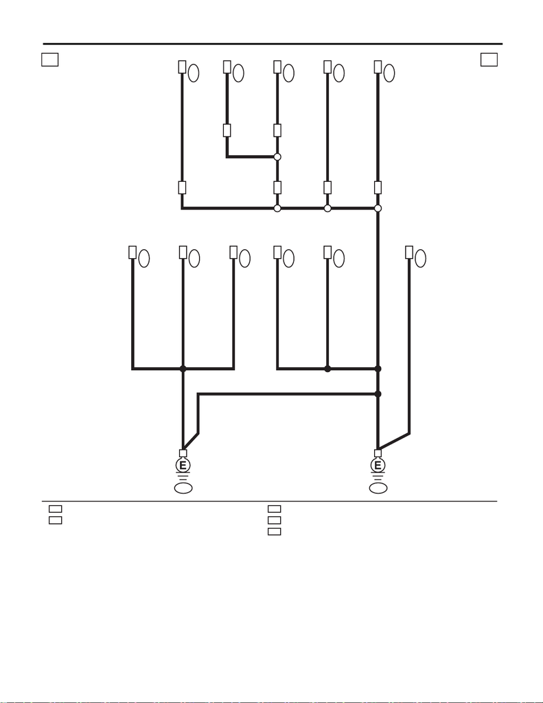

WI-65

Ground Circuit

WIRING SYSTEM

WI-44275

f f

B

B

B

R80

R221

R41

R22

R9

R110

R28

R108

B7

R296

B1

B5

B1

B3

B3

B2

B2

R65

B1

B2

GB-9 GB-10

WP

OP

OT

TP

R211

B5

WP

SH

TP OP

WP

OT SH

REAR COMBINATION LIGHT LH

POWER SEAT LH

REAR DEFOGGER

SEAT BELT SWITCH LH

FRONT DOOR SWITCH LH

REAR DOOR SWITCH LH

SEAT HEATER LH

TPMS & KEYLESS ENTRY CM

TPMS CM

KEYLESS ENTRY CM

RECEIVER

: WITHOUT TPMS

: WITHOUT PUSH BUTTON START

: WITH PUSH BUTTON START

: WITH TPMS

: WITH SEAT HEATER

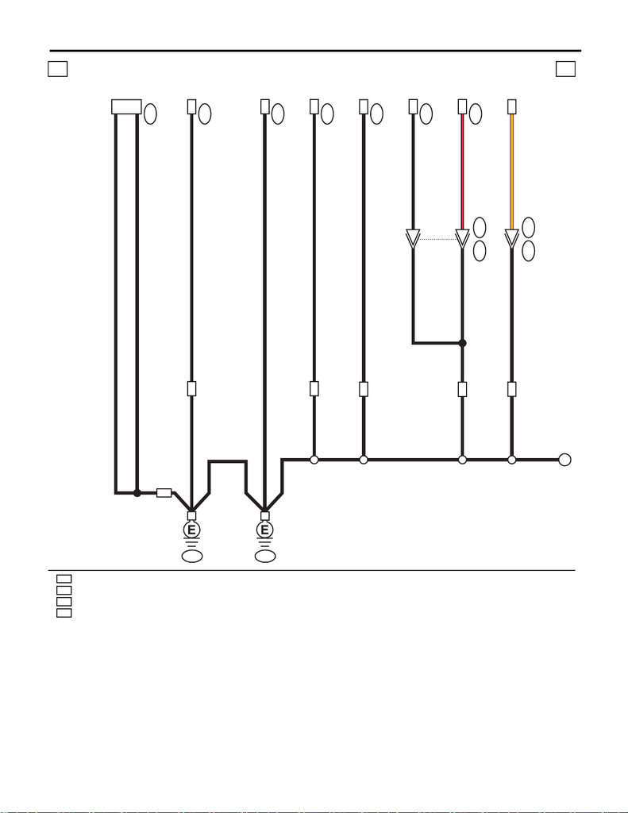

WI-66

Ground Circuit

WIRING SYSTEM

WI-44276

g g

B

B

B

B

B

B

R17

R317

EJ

PM

PM

EJ

R311

B1

R44

SH

B1

R122

B

B

1

BC7

BC6

B

B

B/R

O

B

BB

B

1

AD8

2

AD9

1

GB-11 GB-12

FA

3

14

R34 AD6

9

R33 AD10

FA

PM

SH

EJ

1

G

C:

REAR ACCESSORY POWER SUPPLY SOCKET (CONSOLE)

SEAT HEATER SWITCH

REAR ACCESSORY POWER SUPPLY SOCKET

(CONSOLE)

MULTI SELECT SWITCH (DCCD)

AUDIO AMPLIFIER

AMPLIFIER BRACKET GROUND

SEAT HEATER RH

FUEL PUMP CU

: ENGINE TYPE EJ

: ENGINE TYPE FA

: PREMIUM MODEL

: WITH SEAT HEATER

: ENGINE TYPE FA : 4

ENGINE TYPE EJ : 5

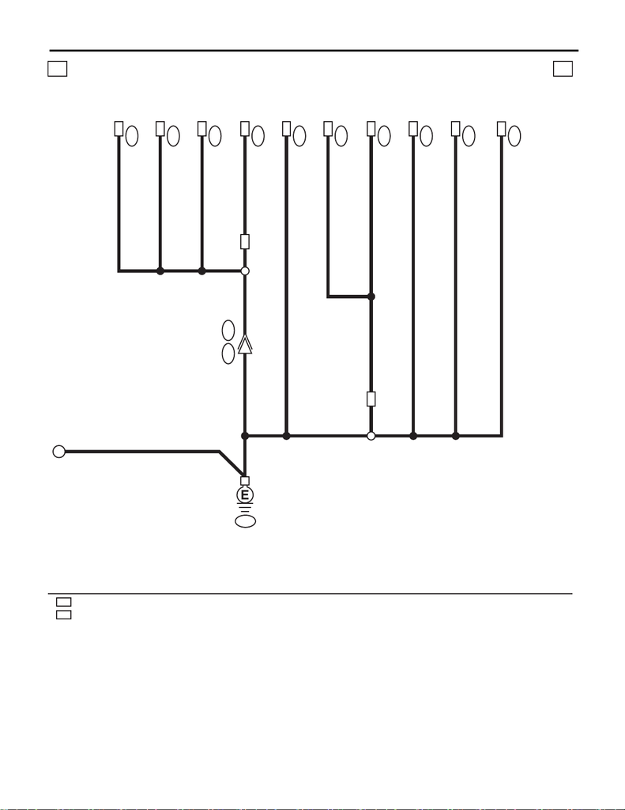

WI-67

Ground Circuit

WIRING SYSTEM

WI-44277

h h

WP

R77

R186

R294

R76

B2

B2

B2

1B

R42

R26

R16

R43

R12

R19

B3

B3

B2

B3

B3

B2

BB

B

9

R24 R60

GB-13

WP

G

FA

FA

: ENGINE TYPE FA

SEAT HEATER SWITCH LH

REAR DOOR SWITCH RH

REAR COMBINATION LIGHT RH

TRUNK OPENER BUTTON

LICENSE PLATE LIGHT RH

LICENSE PLATE LIGHT LH

TRUNK LID LOCK ACTUATOR & SWITCH

SEAT HEATER SWITCH RH

FRONT DOOR SWITCH RH

HIGH-MOUNTED STOP LIGHT

: WITH PUSH BUTTON START

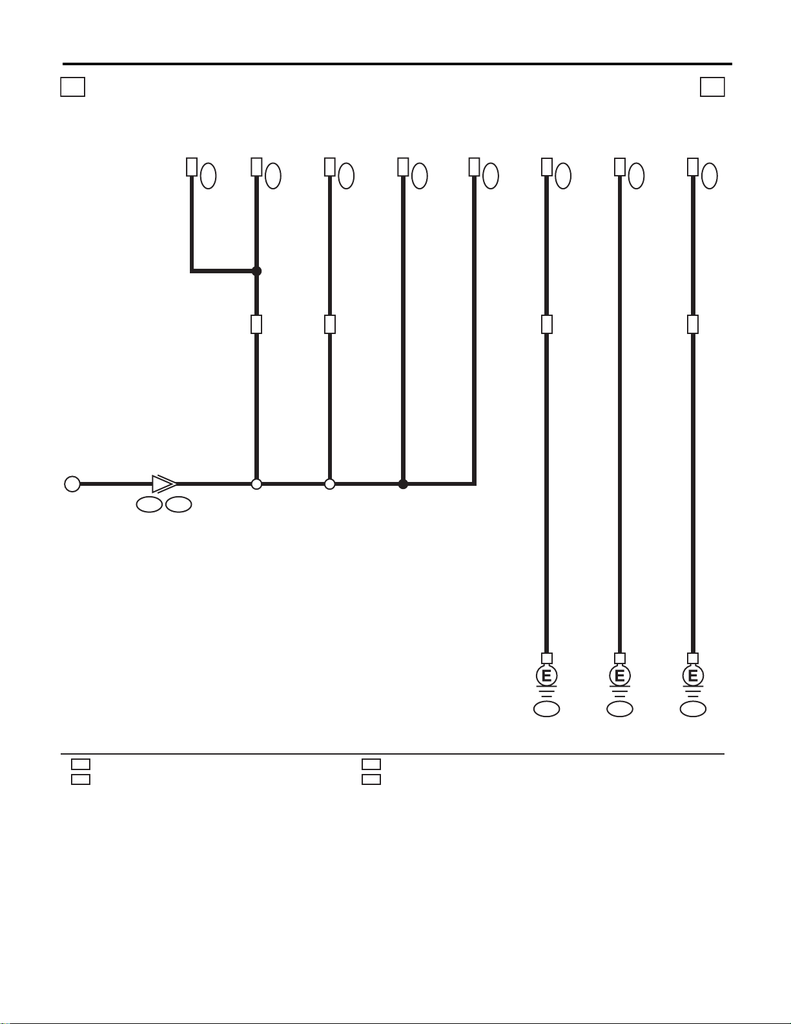

WI-68

Ground Circuit

WIRING SYSTEM

WI-44278

17

i i

B

R139

R56

R52

B90 R50

B

2B

1B

R56

A2B

1B

R55

4BB

B

GVGAP

38B

B1B

B310

GP

1B

F11

B452

B:

A:

ROOM LIGHT

SUNROOF UNIT

SPOT MAP LIGHT

REARVIEW MIRROR

B

B

VDC CM

B

SECONDARY AIR PUMP

POWER STEERING CM

OR

: WITHOUT SUNROOF

WR

: WITH SUNROOF

FA

: ENGINE TYPE FA

EJ

: ENGINE TYPE EJ

WR

OR

FA

EJ

SPOT MAP LIGHT

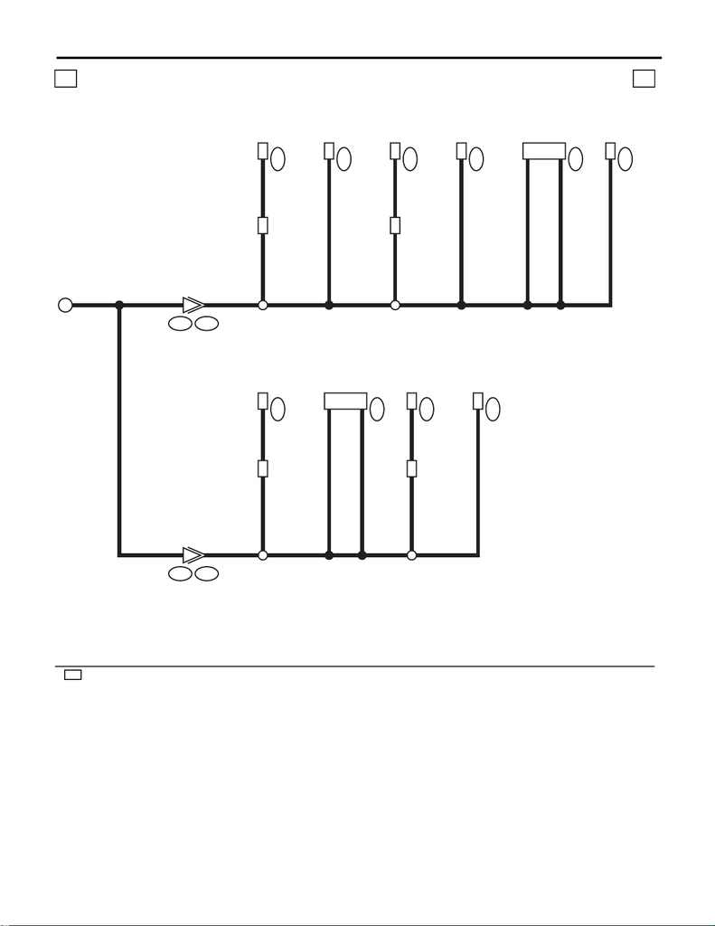

WI-69

Ground Circuit

WIRING SYSTEM

WI-44279

3

3

j j

F

D5

D149

D72

D3

D66

D7

A:

i101 D84

D15

D56

D125

D18

i76 D83

B

5B

10B

B

7

7

B

2B

2B

BA1

B

B

5B

10B

B2

B5

B8

B

B

WP

WP

WP

WP

WP

FRONT DOOR LOCK ACTUATOR RH

PASSENGER'S DOOR LOCK SWITCH

OUTER HANDLE RH

OUTER MIRROR ASSY RH

POWER WINDOW MAIN SWITCH

OUTER HANDLE LH

FRONT POWER WINDOW MOTOR LH

FRONT DOOR LOCK ACTUATOR LH

REMOTE CONTROL MIRROR SWITCH

OUTER MIRROR ASSY LH

: WITH PUSH BUTTON START

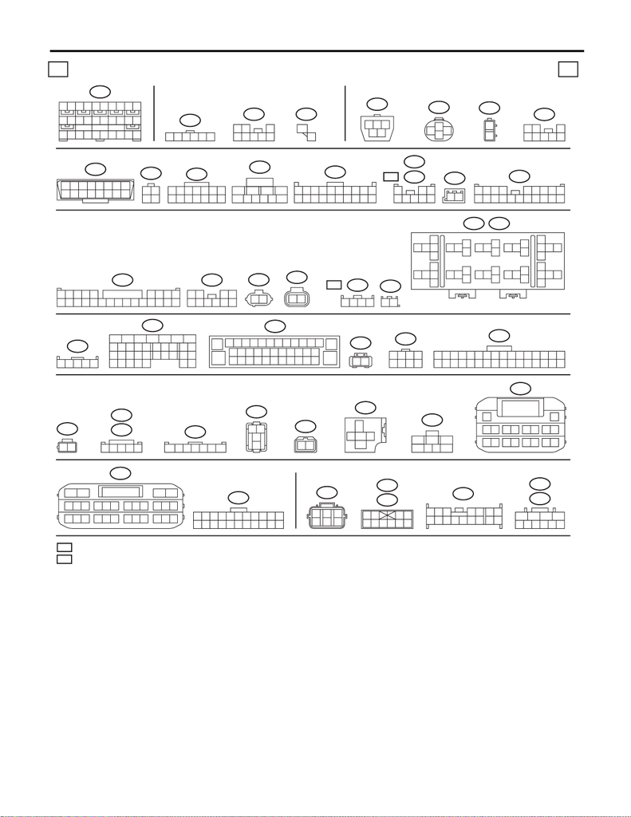

WI-70

Ground Circuit

WIRING SYSTEM

WP

OP

34567

15

14

2

98

1311

17

16

1

18

2719 20 21 22

23

26

25

28 29 3332 3430 31

1210

B280

A:

24

12

34

B57

B150

67893412 5

21 22 23 2417 18 19 201612 1310 11 14 15

B310

23456789

1

10 11 12 13

14

15

26

16 17 18 19 20 21 22 23 24 25

27 28 29 30 31 32 33 34 35 36 37

38

3

4

12

978

6

5

10

D15

D5

B559

B422

WI-44280

B32

12 3

45678

D7

A:

123

89

10

4

11 12 13 14 15 16

56

7

B16

1

2

(GR)

B124

(B)

B143

B:

1234 56789

10 11 12 13 14 15 16 17 18 19 20

k k

2

3

1

4

B10

(GR)

B8

132

45

(GR)

13 1411

12

9

10

8

7

3

42

156

B68

A:

B572

11 12

34

13 14

56

15 16

78

17 18

10

9

12

1234567

8

9

10

11 12 13 14

15 16 17 18 19 20

21 22 23 24 25 26 27 28 29 30

AB6

(Y)

A:

2

1

4

3

B475

D:

34

5

6789

10

12

(GR)

B152

B424

12345

6

7

(B)

9

10

A:

3

5

6

1

2

7

4

8

B70

B:

3

4

56

1

2

7

B558

123456789

10

11 12 13 14 15 16 17 18 19 20

B71

3

4

2

1

56

D3

(GR)

12

B396

(BR)

21

B321

(B)

1

76589

10

342

D72

D18

B177

12

(GR)

4

12

5

13

1

9

8

16

2

10

7

15

3

11

6

14

B40

(B)

12

B181

341

2

B180

OP

:

B180

321

87654

B116

WP

:

134

678

B367

2

5

1

2

345

B575

123

456789

10 11

12 13 14 15 16 17 18 19 20 21 22

(B)

B452

B:

21

1

2

3

4

B426

(B)

AD7

AD8 AD9

B231

123456

12 3

45678

1

2

5341

2

24

5

3

17

9

8

6

B220

10 11

12

13

14 15

16

18

19 21 22

20

17

32 33

34

35

28262423

25

27

29

30

31

36 37

38

40

41 43 44

42

39

B225

(GR)

B164

12

B380

896745231

15 1613 1411 1210

24 2522 2320 2118 1917 31 3229 3027 2826

B573B:

17 18 19 20 21 22 23 24 25 26 27 28

567 89

10 11 12 13 14 15 16

12 34

21

: WITH PUSH BUTTON START

: WITHOUT PUSH BUTTON START

LIST OF CONNECTORS

RELAY HOLDER

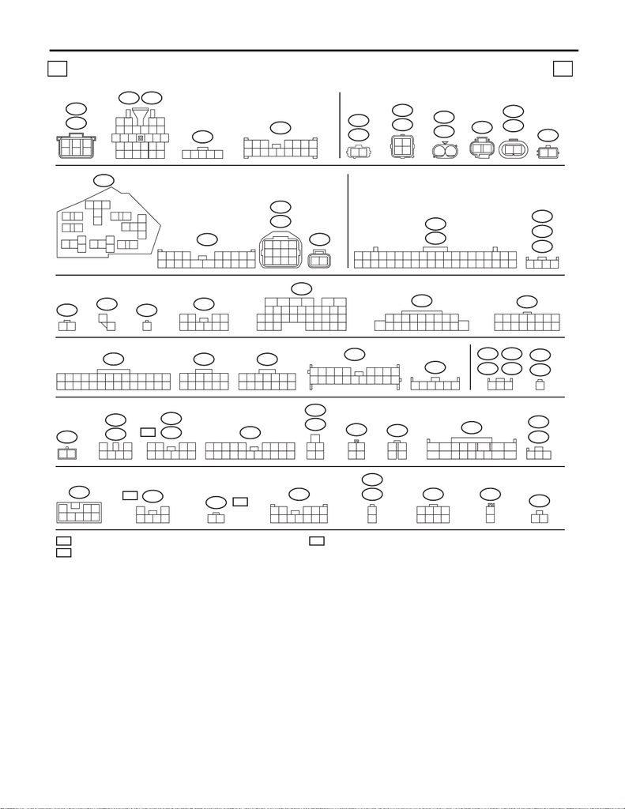

WI-71

Ground Circuit

WIRING SYSTEM

i195

12345 6789

10 11 12 13 14 15 16 17 18 19 20

OR

WR

21 22 23 24 28 29 30 31 32 33 34 35 36 37 38 39 40

19

18

20

26

25

27

11 12

9

10

7856341

2

15 1613 14 17

i88

i10

1

i29

i150

123

4567

89

10 11 12 13 14

R108

1

2

WI-44281

i87

C:

123456789

15 16 17 18 19 20 21 22 23 24

10 11 12 13 14

25 26 27 28

l l

i24

1

2

28 29 30

31 32 33 34 35

1

23

4

56

98

27

7

151413121110 16

2322 24 25 26

17

i84

19

18

21

20

C:

5

7

6

98

19

18

20

132

4

1514131211 1716

10

i85

A:

11 12

9

10

78

65341

2

i122

(B)

A:

123

R12

R9

R22

R16

12345678

9

10 11 12 13 14 15 16

i86

B:

341

2

i28

i22

i13

(GR)

(GR)

34

56789

10

12

i50

A:

R80

13

4

6

78

2

5

63451

2

i234

(GR)

R26

R28

5

6

34

21

R44

R41

12

34

12

34

R42

10

13

345 6

14 15 16 17

1211

12 78

9

R50

(GR)

21

R110

(B)

F11

12

F13

12

(GR)

F10

(GR)

F14

(GR)

F15

(GR)

12

F126

(GR)

F125

(GR)

1234

5678

9

10 11 12

i23

21

(B)

R65

(B)

R17

1

R76

1

2

R77

(L)

R43

34

12

R60

12 345

6789

10 11 12

R55

48

3

765

1

2

D84D83

19

18

20 21 22

1514131211

1

3

24

5

7

6

98

10

17

25

24

26 27 2823

16

R56

OR

:

5634

21

R56

WR

A: :

21

1234

56789

10 11 12 13 14 15 16 17 18 19 20

A:

F37

24

23

25

12 13 14

15

16

26

2221

20

19

1817

10 11

2

4

5

13

7698

F27

D149

12

3

4

567

89

10 11 12

14 15 1613

12

F17

D125

12345

(GR)

F6

(GR)

F21

12

34

(B)

F47

(B)

F5

12

R19

12

R34

123

161514

546789

17 18 19 2013121110

123

R52

3

4

2

1

56

D56

D66

F134

(GR)

12

LIST OF CONNECTORS

: WITHOUT SUNROOF

: WITH SUNROOF

RELAY HOLDER

R186

R122

(GR)

EJ

:

12

34

56789

10

R33

: ENGINE TYPE EJ

EJ

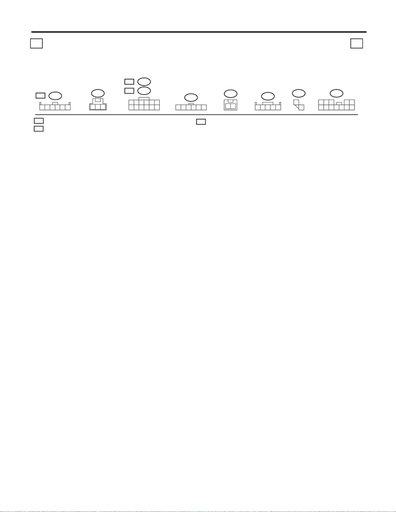

WI-72

Ground Circuit

WIRING SYSTEM

WI-44282

m m

R311

1

2

R317

C:

123 45

6 7 8 9 10 11 12

R139

321

R294

21

(BR)

R221

R211

11 12

9

10

78

65341

2

OP

:

WP

:

OP

WP

63451

2

R122

FA

:

R284

123456

R296

3

421

5

FA

LIST OF CONNECTORS

: WITHOUT PUSH BUTTON START

: WITH PUSH BUTTON START

: ENGINE TYPE FA